# Exploratory Plots

## Plot an example dance

```r
example_day  = unique(hd$day)[length(unique(hd$day))]#last day
example_bee = "22b"
print(paste("First dance for", example_bee, "for each condition on", example_day))
```

```
## [1] "First dance for 22b for each condition on 20250128"
```

```r
daybee_lst = FirstDanceCond(dta = hd,
                        subset = day %in% example_day & ID %in% example_bee)
```

```
## [1] "First dance for each condition after subsetting"
##            [,1]
## vertical   "22b_00002_08:12:00_20250128"
## horizontal "22b_00012_08:36:00_20250128"
## antisolar  "22b_2025-01-28 07-57-05_08:58:00_20250128"
## solar      "22b_2025-01-28 10-44-09_11:44:00_20250128"
## zenith     NA
## tilted     "22b_00010_08:29:00_20250128"
```

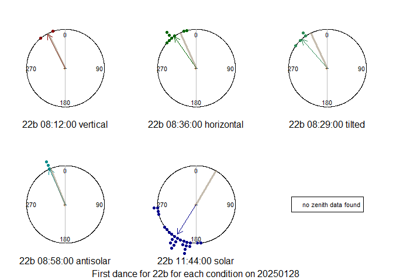

```r
# Plot the example subset
Plt_subs(subs = daybee_lst$example_subs,
         angle_for = "sun",
         cond_cols = cond_cols,
         title = paste("First dance for", example_bee, "for each condition on", example_day)
         )
```

At least for this subset, the dances follow the expected pattern. For both vertical and horizontal dances, the average waggle run aligns with the feeder direction. With antisolar skylight the waggle runs are also aligned, while solar skylight is mistaken for antisolar skylight, resulting in a 180° turn.

We can also plot these dances with the feeder direction subtracted, so that the feeder falls at 0°.

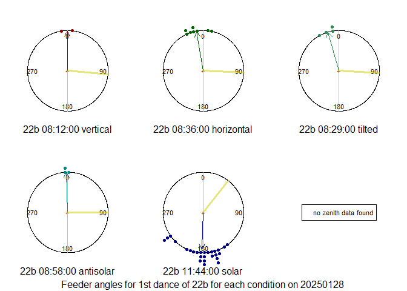

```r
#Plot using the feeder as the frame of reference
Plt_subs(subs = daybee_lst$example_subs,
         angle_for = "feeder",
         title = paste("Feeder angles for 1st dance of", example_bee, "for each condition on", example_day))
```

## Low elevation

```r
# Select the first dance for each condition at low sun elevation.
print("First dance for low sun elevations")
```

```
## [1] "First dance for low sun elevations"
```

```r
lowel_subs = FirstDanceCond(
  hd,
  sun_el < 15
)$example_subs
```

```
## [1] "First dance for each condition after subsetting"
##            [,1]
## vertical   "22b_00041_17:37:00_20250119"
## horizontal "22b_00054_18:00:00_20250119"
## antisolar  "95r_2025-01-27 17-32-37_18:32:00_20250127"
## solar      NA
## zenith     "90r_2025-01-27 17-22-33_18:23:00_20250127"
## tilted     "20y_00051_17:55:00_20250127"
```

```r
Plt_subs(
  subs = lowel_subs,
  angle_for = "feeder",
  title = paste("Feeder angles for low sun elevations")
)
```

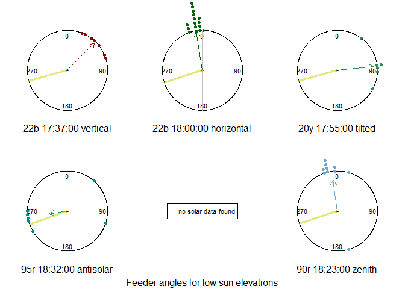

## Medium elevation

```r
# Select the first dance for each condition at medium sun elevation.
print(paste("First dance for medium sun elevations"))
```

```
## [1] "First dance for medium sun elevations"
```

```r
medel_subs = FirstDanceCond(
  hd,
  sun_el > 30 & sun_el < 45
)$example_subs
```

```
## [1] "First dance for each condition after subsetting"
##            [,1]
## vertical   "22b_00011_08:21:00_20250120"
## horizontal "22b_00019_08:36:00_20250120"
## antisolar  "73b_2025-01-22 15-00-37_16:02:00_20250122"
## solar      "66b_2025-01-27 15-01-25_16:04:00_20250127"
## zenith     NA
## tilted     "20y_00035_15:28:00_20250127"
```

```r
Plt_subs(
  subs = medel_subs,
  angle_for = "feeder",
  title = paste("Feeder angles for medium sun elevations")
)
```

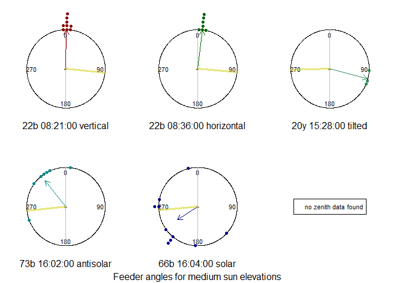

## High elevation

```r
# Select the first dance for each condition at high sun elevation.
print(paste("First dance for high sun elevations"))
```

```
## [1] "First dance for high sun elevations"
```

```r
higel_subs = FirstDanceCond(
  hd,
  sun_el > 75
)$example_subs
```

```
## [1] "First dance for each condition after subsetting"
##            [,1]
## vertical   "22b_00035_12:17:00_20250120"
## horizontal "69r_00041_12:48:00_20250120"
## antisolar  "87r_antisolar-.2025-01-21 11-22-26_12:24:00_20250121"
## solar      "22b_solar_2025-01-21 12-03-51_13:05:00_20250121"
## zenith     NA
## tilted     "20y_00028_12:20:00_20250127"
```

```r
Plt_subs(
  subs = higel_subs,
  angle_for = "feeder",
  title = paste("Feeder angles for high sun elevations")
)
```

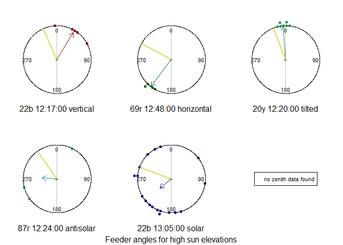

# Plot the raw dance data

## Plot an example dance

For example we can look at the longest dance in the dataset, by Blue 73, recorded on 2025.01.19 at 16:51.

```r
longest_id_d = u_id_d[which.max(sapply(
  u_id_d,
  function(i) {
    with(
      subset(hd, ID_d %in% i),
      max(waggle_run)
    )
  }
))]

par(pty = 's')
par(mfrow = c(1,1), mar = c(0,0,0,0))
PltDance(ids = '73b_00027_16:51:00_20250119',
         dtf = hd,
         rlim = 100,
         cx = 1.0)
segments(x0 = 0, x1 = 0,
        y0 = 0, y1 = 100,
        col = "yellow3")
with(subset(hd, ID_d %in% '73b_00027_16:51:00_20250119' & waggle_run %in% c(20, 40, 60, 80)),
     {
points(x = waggle_run*sin(rad(dance_sun_angle)),
     y = waggle_run*cos(rad(dance_sun_angle)),
     labels = paste(' run', waggle_run),
     col = hcl.colors(4, palette = "dark2"),
     pch = 19)
text(x = waggle_run*sin(rad(dance_sun_angle)),
     y = waggle_run*cos(rad(dance_sun_angle)),
     labels = paste(' run', waggle_run),
     col = hcl.colors(4, palette = "dark2"),
     cex = 0.8,
     adj = c(0,0))
     }
)
```

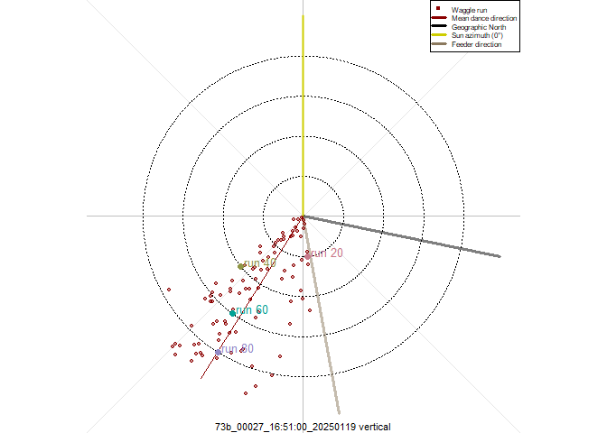

```r
legend(x = 'topright',
       legend = c('Waggle run',
                  'Mean dance direction',
                  'Geographic North',
                  'Sun azimuth (0°)',
                  'Feeder direction'),
       col = c('darkred',
               'darkred',
               'black',
               'yellow3',
               'navajowhite4'
               ),
       pch = c(21,NA,NA,NA,NA),
       lty = c(NA, 1, 1, 1, 1),
       lwd = c(2,3,3,3,3),
       cex = 0.5
       )
```

## Plot all raw dances

**Click to expand dance plots**

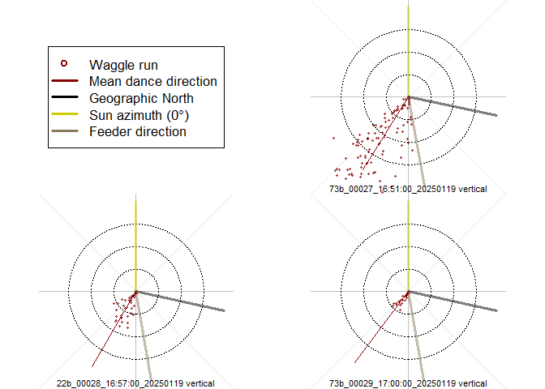

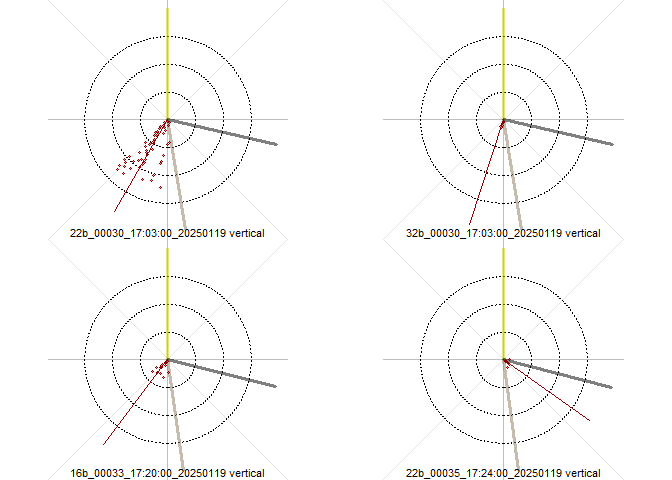

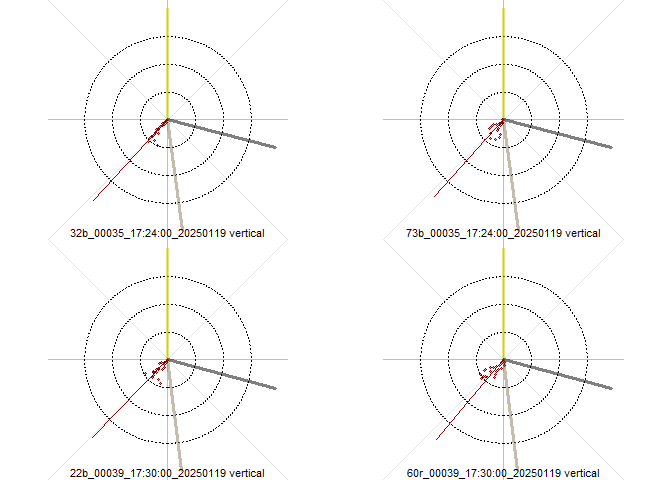

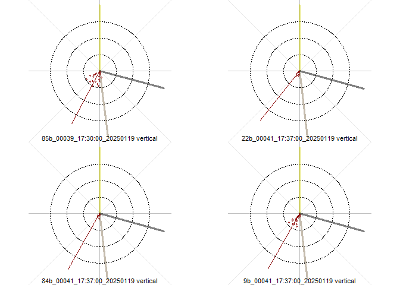

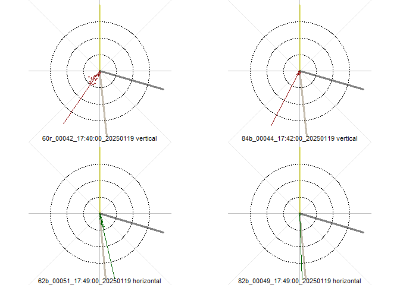

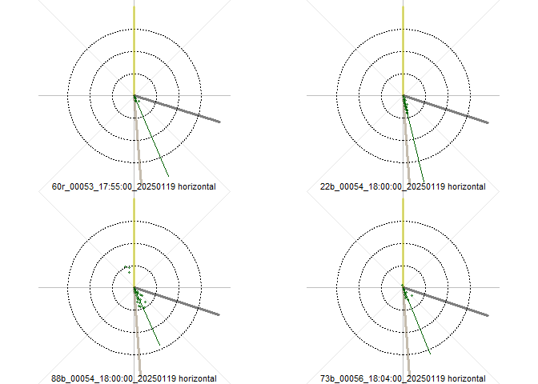

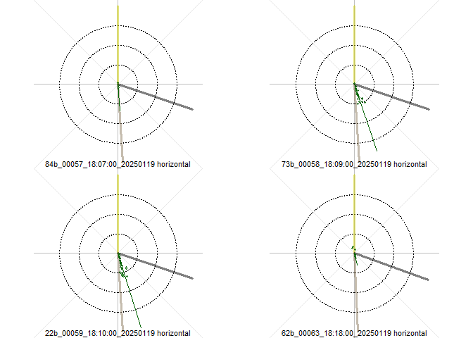

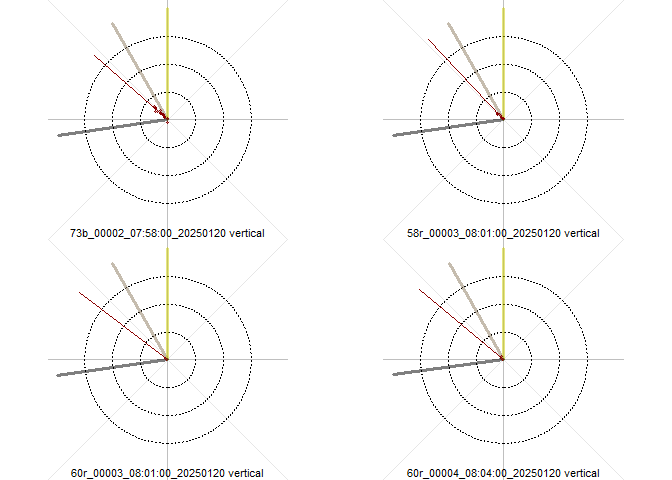

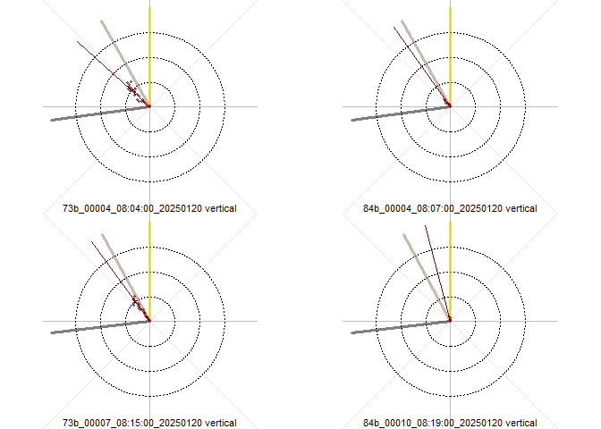

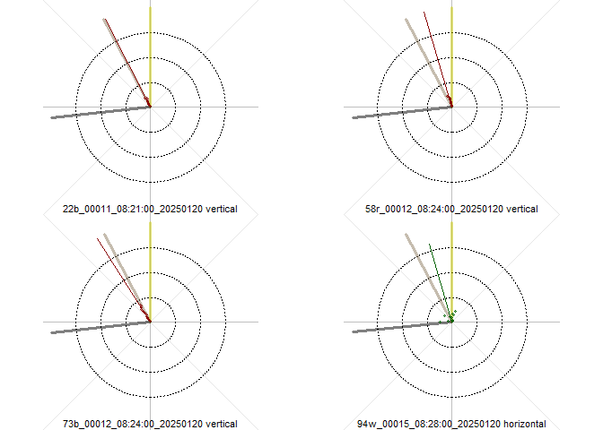

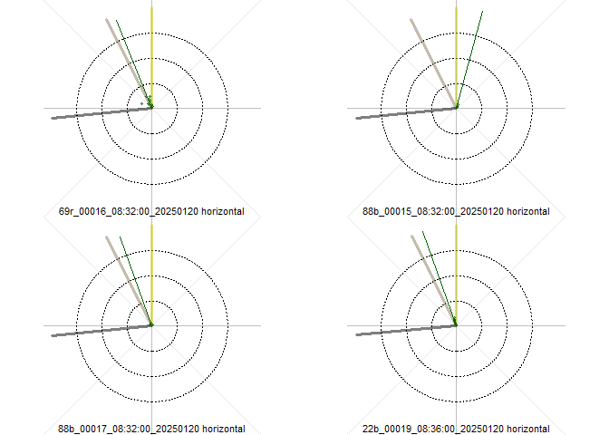

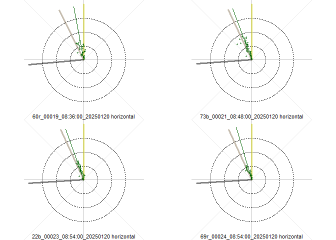

[90 more figures not shown]

```r
#reorganise u_id_d by date of dance
dance_date = sapply(
  X = u_id_d,
  FUN = function(i) {
    with(
      subset(hd, ID_d %in% i),
      unique(sast_time)
    )
  }
)
u_id_d = u_id_d[order(dance_date)]

par(mfrow = c(2, 2),
    mar = c(0,0,0,0))
par(pty = 's')
#add legend to 1st page
plot(x = NULL,
     xlim = c(-1,1),
     ylim = c(-1,1),
     pch = 19,
     axes = FALSE,
     xlab = '',
     ylab = '',
     main = ''
)
legend(x = 'center',
       legend = c('Waggle run',
                  'Mean dance direction',
                  'Geographic North',
                  'Sun azimuth (0°)',
                  'Feeder direction'),
       col = c('darkred',
               'darkred',
               'black',
               'yellow3',
               'navajowhite4'
               ),
       pch = c(21,NA,NA,NA,NA),
       lty = c(NA, 1, 1, 1, 1),
       lwd = c(2,3,3,3,3),
       cex = 1.3
       )
#loop through individuals
PltDance(ids = u_id_d,
         dtf = hd,
         cx = 1.0)
```

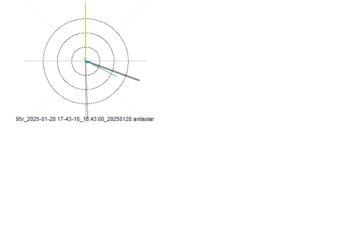

```r
#save as a plot
invisible({
  pdf(
    file = "Plots/All_dances.pdf",
    paper = 'a4',
    onefile = TRUE
  )
  pdfdev = dev.cur()
  par(
    mfrow = c(2, 2),
    mar = c(0, 0, 0, 0)
  )
  par(pty = 's')

  #add legend to 1st page
  plot(
    x = NULL,
    xlim = c(-1, 1),
    ylim = c(-1, 1),
    pch = 19,
    axes = FALSE,
    xlab = '',
    ylab = '',
    main = ''
  )
  legend(
    x = 'center',
    legend = c(
      'Waggle run',
      'Mean dance direction',
      'Geographic North',
      'Sun azimuth (0°)',
      'Feeder direction'
    ),
    col = c(
      'darkred',
      'darkred',
      'black',
      'yellow3',
      'navajowhite4'
    ),
    pch = c(21, NA, NA, NA, NA),
    lty = c(NA, 1, 1, 1, 1),
    lwd = c(2, 3, 3, 3, 3),
    cex = 2.0
  )
  #loop through individuals
  PltDance(
    ids = u_id_d,
    dtf = hd,
    cx = 1.0
  )
  dev.off(which = pdfdev)
})
```

# Solar Ephemeris

Using the vertical dances, it should be possible to identify the solar ephemeris functions used by those individuals that danced repeatedly throughout the day.

First set up the reference solar ephemeris for all times on a median day.

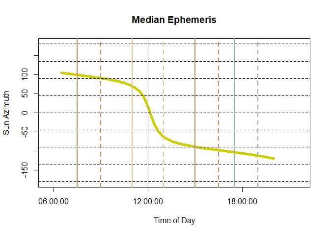

```r
hive = r"(25° 34' 18" S, 31° 10' 48" E)" # N.B. this string contains literal " so needs wrapping in r"()"

# Define coordinates (lon, lat)
hive = Dms2decimal(hive)


# sequence from times from 1h before 1st experiment to 1h after last, by 5 minutes
time_seq = seq(from = min(exper_times)-60*60,
               to  = max(exper_times)+60*60,
               by = 5*60)
med_date = with(hd, median(as.numeric(paste(day))))
time_code_sast = as.POSIXct(paste(med_date, "00:00:00"),#midnight on median day
                                      tz = "Africa/Johannesburg",
                                      format = "%Y%m%d %H:%M:%OS") + #South African Standard time
              time_seq
#convert to UTC
time_code_utc = as.POSIXct(time_code_sast, tz = "UTC")#UTC time

saz_seq = mapply(
                   FUN = GetSaz,
                   tm = time_code_utc,
                   lon = hive['longitude'],
                   lat = hive['latitude']
                   )
par(mfrow = c(1,1))
#plot all vertical dances

plot(x = GetToD(format(time_code_sast, "%H:%M:%S")),
    y = Mod360.180(saz_seq),
    xlim = c(20400,78060),#"06:40:00 CET" "22:41:00 CET"
    ylim = c(-1,1)*180,
    xlab = 'Time of Day',
    ylab = 'Sun Azimuth',
    main = 'Median Ephemeris',
    type = 'l',
    col = 'yellow3',
    lwd = 5
)
abline(h = -4:4*c(45),
      lty = 2) #limits
abline(v =  12*60*60, #as.numeric(as.POSIXct("1970-01-01 12:00:00 UTC"))
      lty = 3)

#add lines indicating the approximate expected start and end of each experiment
abline(v = exper_times,
       col = time_cols,
       lty = c(1,2),
       lwd = 2
       )
```

## Check dance times

Blue 22 and blue 66 both danced very frequently, so we can start by checking when they danced.

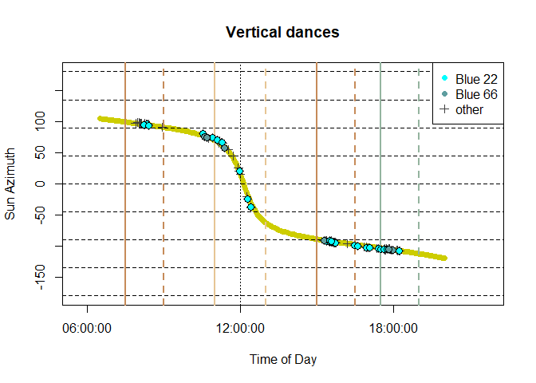

```r
par(mfrow = c(1,1))
#plot all vertical dances
plot(x = GetToD(format(time_code_sast, "%H:%M:%S")),
    y = Mod360.180(saz_seq),
    xlim = c(20400,78060),#"06:40:00 CET" "22:41:00 CET"
    ylim = c(-1,1)*180,
    xlab = 'Time of Day',
    ylab = 'Sun Azimuth',
    main = 'Vertical dances',
    type = 'l',
    col = 'yellow3',
    lwd = 7
)

with(subset(hd, condition %in% c("vertical") ),
     {
     points(x = GetToD(time),
          y = Mod360.180(sun_az),
          pch = 3,#cross
          col = 'gray25'
     )
     abline(h = -4:4*c(45),
            lty = 2) #limits
     abline(v =  12*60*60, #as.numeric(as.POSIXct("1970-01-01 12:00:00 UTC"))
            lty = 3)
     }
)
#add lines indicating the approximate expected start and end of each experiment
abline(v = exper_times,
       col = time_cols,
       lty = c(1,2),
       lwd = 2
       )
#plot dances by bees of interest
with(subset(hd, condition %in% c("vertical") &
              ID %in% c('22b', '66b')
            ),
     {
     points(x = GetToD(time),
          y = Mod360.180(sun_az),
          pch = 21,
          col = 'black',
          cex = 1.2,
           bg = adjustcolor(sapply(X = as.character(ID),
                        FUN = switch,
                        `22b` = 'cyan',
                        `66b` = 'cadetblue',
                        'red',#if these show up, oops!
                        alpha.f = 0.25)
           )
     )
     }
)
legend(x = 'topright',
       legend = c("Blue 22",
                  "Blue 66",
                  "other"),
       col=  c("cyan",
               "cadetblue",
               "gray25"),
       pch = c(19, 19,
               3)
)
```

It looks like we have the best chance with blue 22, for which we have the most dances during the rapid azimuth change period in the middle of the day.

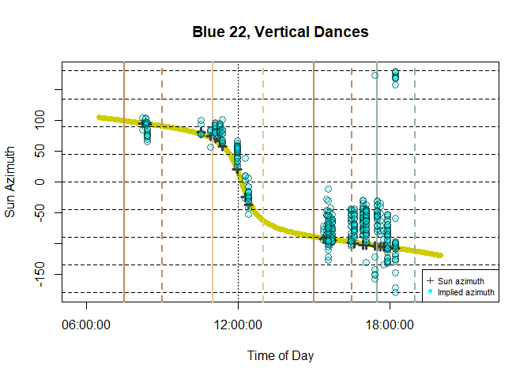

```r
par(mfrow = c(1,1))
#plot all vertical dances
plot(x = GetToD(format(time_code_sast, "%H:%M:%S")),
    y = Mod360.180(saz_seq),
    xlim = c(20400,78060),#"06:40:00 CET" "22:41:00 CET"
    ylim = c(-1,1)*180,
    xlab = 'Time of Day',
    ylab = 'Sun Azimuth',
    main = 'Blue 22, Vertical Dances',
    type = 'l',
    col = 'yellow3',
    lwd = 7
)
with(subset(hd, condition %in% c("vertical") &
              ID %in% c('22b')
            ),
     {
     points(x = sort(GetToD(time)),
          y = Mod360.180(sun_az)[order(GetToD(time))],
          pch = 3,#cross
          lwd = 3,
          col = 'gray25'
     )
     abline(h = -4:4*c(45),
            lty = 2) #limits
     abline(v =  12*60*60, #as.numeric(as.POSIXct("1970-01-01 12:00:00 UTC"))
            lty = 3)
     }
)
#add lines indicating the approximate expected start and end of each experiment
abline(v = exper_times,
       col = time_cols,
       lty = c(1,2),
       lwd = 2
       )
#plot dances by bees of interest
with(subset(hd, condition %in% c("vertical") &
              ID %in% c('22b')
            ),
     {
     points(x = GetToD(time),
          y = Mod360.180(dance_sun_angle + (sun_az - feeder_az)),
          pch = 21,
          cex = 1.2,
          col = adjustcolor('black',
                            alpha.f = 0.5),
           bg = adjustcolor('cyan',
                        alpha.f = 0.25)
     )
     }
)
legend(
  x = 'bottomright',
  legend = c(
    "Sun azimuth",
    "Implied azimuth"
  ),
  col = c("gray25", "cyan"),
  pch = c(3, 19),
  cex = 0.7
)
```

How similar is the population?

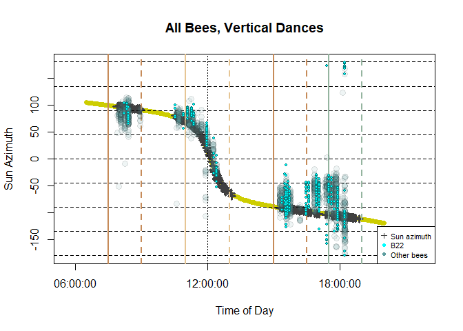

```r
par(mfrow = c(1,1))
#plot all vertical dances
plot(x = GetToD(format(time_code_sast, "%H:%M:%S")),
    y = Mod360.180(saz_seq),
    xlim = c(20400,78060),#"06:40:00 CET" "22:41:00 CET"
    ylim = c(-1,1)*180,
    xlab = 'Time of Day',
    ylab = 'Sun Azimuth',
    main = 'All Bees, Vertical Dances',
    type = 'l',
    col = 'yellow3',
    lwd = 7
)
with(hd,
     {
     points(x = sort(GetToD(time)),
          y = Mod360.180(sun_az)[order(GetToD(time))],
          pch = 3,#cross
          lwd = 3,
          col = 'gray25'
     )
     abline(h = -4:4*c(45),
            lty = 2) #limits
     abline(v =  12*60*60, #as.numeric(as.POSIXct("1970-01-01 12:00:00 UTC"))
            lty = 3)
     }
)
#add lines indicating the approximate expected start and end of each experiment
abline(v = exper_times,
       col = time_cols,
       lty = c(1,2),
       lwd = 2
       )
#plot dances other bees
with(subset(hd, condition %in% c("vertical") &
            !(ID %in% c('22b')) ),
     {
     points(x = GetToD(time),
          y = Mod360.180(dance_sun_angle + (sun_az - feeder_az)),
          pch = 21,
          cex = 1.2,
          col = adjustcolor('black',
                            alpha.f = 0.1),
           bg = adjustcolor('cadetblue',
                        alpha.f = 0.1)
     )
     }
)

#plot dances by bees of interest
with(subset(hd, condition %in% c("vertical") &
              ID %in% c('22b')
            ),
     {
     points(x = GetToD(time),
          y = Mod360.180(dance_sun_angle + (sun_az - feeder_az)),
          pch = 21,
          cex = 0.5,
          col = adjustcolor('black',
                            alpha.f = 0.5),
           bg = adjustcolor('cyan',
                        alpha.f = 1.0)
     )
     }
)

legend(
  x = 'bottomright',
  legend = c(
    "Sun azimuth",
    "B22",
    "Other bees"
  ),
  col = c("gray25", "cyan", "cadetblue"),
  pch = c(3, 19, 19),
  cex = 0.7
)
```

It looks like B22 is fairly representative: all bees are initially slow to adjust to the sun’s accelerating westward movement after 11:00, but have adjusted by 12:00. In the afternoon dances start at the correct angle, appear not to adjust at all during the following hour, but begin to adjust around 17:30. A simple description could be achieved with a piecewise regression, with a constant rate of change in solar azimuth between 07:00 and 11:00, another (faster) rate of change between 11:00 and 13:00, and likely the same morning rate of change repeated again between 13:00 and 19:00.

## Ephemeris error

What does the error distribution look like? Is it symmetrical, or is there a systematic offset?

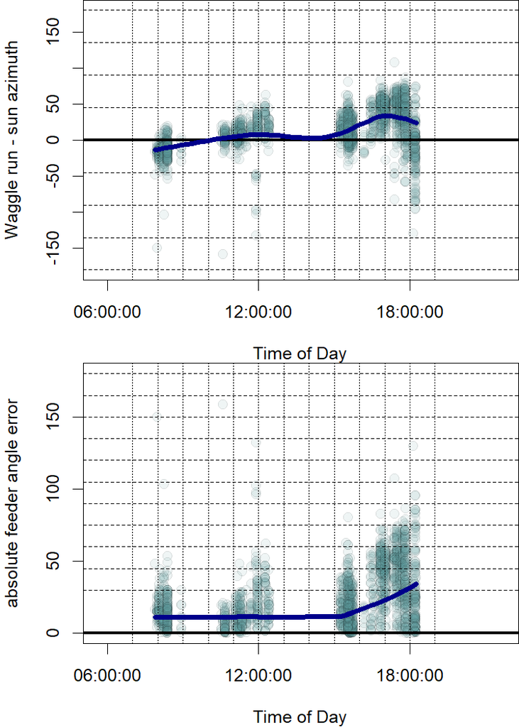

```r
par(
  mfrow = c(2, 1),
  mar = c(4, 4, 0, 0)
)
#plot dance offset from true feeder angle
with(
  subset(
    hd,
    condition %in% c("vertical")
  ),
  {
    plot(
      x = GetToD(time),
      y = Mod360.180(deg(feeder_angle)),
      xlim = c(20400, 78060), #"06:40:00 CET" "22:41:00 CET"
      ylim = c(-1, 1) * 180,
      xlab = 'Time of Day',
      ylab = 'Waggle run - sun azimuth',
      main = '', #'Vertical Dances',
      pch = 21,
      cex = 1.2,
      col = adjustcolor(
        'black',
        alpha.f = 0.1
      ),
      bg = adjustcolor(
        'cadetblue',
        alpha.f = 0.1
      )
    )
  }
)
abline(h = 0, lwd = 3) #expected
abline(h = -4:4 * c(45), lty = 2) #limits
abline(v = 7:19 * 60*60, lty = 3) #hours
abline(
  v = 12 * 60 * 60, #as.numeric(as.POSIXct("1970-01-01 12:00:00 UTC"))
  lty = 3
)
with(
  subset(
    hd,
    condition %in% c("vertical")
  ),
  {
    lines(
      loess.smooth(
        x = GetToD(
          time
        ),
        y = Mod360.180(deg(
          feeder_angle
        ))
      ),

      col = 'darkblue',
      lwd = 5
    )
  }
)

#absolute error

#plot dances other bees
with(
  subset(
    hd,
    condition %in% c("vertical")
  ),
  {
    plot(
      x = GetToD(time),
      y = abs(Mod360.180(deg(
        feeder_angle
      ))),
      xlim = c(20400, 78060), #"06:40:00 CET" "22:41:00 CET"
      ylim = c(0, 1) * 180,
      xlab = 'Time of Day',
      ylab = 'absolute feeder angle error',
      main = '', #'Vertical Dances',
      pch = 21,
      cex = 1.2,
      col = adjustcolor(
        'black',
        alpha.f = 0.1
      ),
      bg = adjustcolor(
        'cadetblue',
        alpha.f = 0.1
      )
    )
  }
)
abline(h = 0, lwd = 3) #expected
abline(h = 2:12 * c(15), lty = 2) #limits
abline(v = 7:19 * 60*60, lty = 3) #hours
abline(
  v = 12 * 60 * 60, #as.numeric(as.POSIXct("1970-01-01 12:00:00 UTC"))
  lty = 3
)
with(
  subset(
    hd,
    condition %in% c("vertical")
  ),
  {
    lines(
      LogitLoess(
        x = GetToD(
          time
        ),
        y = abs(Mod360.180(deg(
          feeder_angle
        ))),
        absangle = TRUE
      ),

      col = 'darkblue',
      lwd = 5
    )
  }
)
```

## Horizontal dances

Is this similar for the horizontal

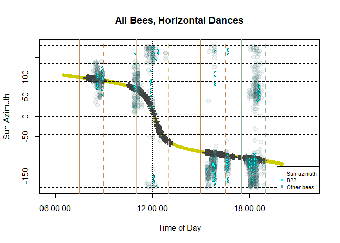

```r
par(mfrow = c(1,1))
#plot all vertical dances
plot(x = GetToD(format(time_code_sast, "%H:%M:%S")),
    y = Mod360.180(saz_seq),
    xlim = c(20400,78060),#"06:40:00 CET" "22:41:00 CET"
    ylim = c(-1,1)*180,
    xlab = 'Time of Day',
    ylab = 'Sun Azimuth',
    main = 'All Bees, Horizontal Dances',
    type = 'l',
    col = 'yellow3',
    lwd = 7
)
with(hd,
     {
     points(x = sort(GetToD(time)),
          y = Mod360.180(sun_az)[order(GetToD(time))],
          pch = 3,#cross
          lwd = 3,
          col = 'gray25'
     )
     abline(h = -4:4*c(45),
            lty = 2) #limits
     abline(v =  12*60*60, #as.numeric(as.POSIXct("1970-01-01 12:00:00 UTC"))
            lty = 3)
     }
)
#add lines indicating the approximate expected start and end of each experiment
abline(v = exper_times,
       col = time_cols,
       lty = c(1,2),
       lwd = 2
       )
#plot dances other bees
with(subset(hd, condition %in% c("horizontal") &
            !(ID %in% c('22b')) ),
     {
     points(x = GetToD(time),
          y = Mod360.180(dance_sun_angle + (sun_az - feeder_az)),
          pch = 21,
          cex = 1.2,
          col = adjustcolor('black',
                            alpha.f = 0.1),
           bg = adjustcolor('cadetblue',
                        alpha.f = 0.1)
     )
     }
)

#plot dances by bees of interest
with(subset(hd, condition %in% c("horizontal") &
              ID %in% c('22b')
            ),
     {
     points(x = GetToD(time),
          y = Mod360.180(dance_sun_angle + (sun_az - feeder_az)),
          pch = 21,
          cex = 0.5,
          col = adjustcolor('black',
                            alpha.f = 0.5),
           bg = adjustcolor('cyan',
                        alpha.f = 1.0)
     )
     }
)

legend(
  x = 'bottomright',
  legend = c(
    "Sun azimuth",
    "B22",
    "Other bees"
  ),
  col = c("gray25", "cyan", "cadetblue"),
  pch = c(3, 19, 19),
  cex = 0.7
)
```

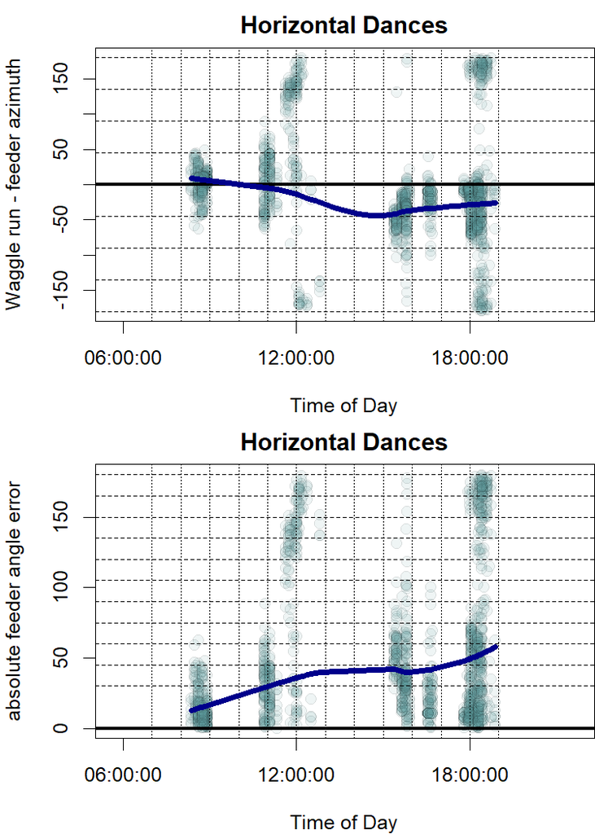

```r
par(
  mfrow = c(2, 1),
  mar = c(4, 4, 2, 0)
)
#plot dance offset from true feeder angle
with(
  subset(
    hd,
    condition %in% c("horizontal")
  ),
  {
    plot(
      x = GetToD(time),
      y = Mod360.180(deg(feeder_angle)),
      xlim = c(20400, 78060), #"06:40:00 CET" "22:41:00 CET"
      ylim = c(-1, 1) * 180,
      xlab = 'Time of Day',
      ylab = 'Waggle run - feeder azimuth',
      main = 'Horizontal Dances',
      pch = 21,
      cex = 1.2,
      col = adjustcolor(
        'black',
        alpha.f = 0.1
      ),
      bg = adjustcolor(
        'cadetblue',
        alpha.f = 0.1
      )
    )
  }
)
abline(h = 0, lwd = 3) #expected
abline(h = -4:4 * c(45), lty = 2) #limits
abline(v = 7:19 * 60*60, lty = 3) #hours
abline(
  v = 12 * 60 * 60, #as.numeric(as.POSIXct("1970-01-01 12:00:00 UTC"))
  lty = 3
)
with(
  subset(
    hd,
    condition %in% c("horizontal")
  ),
  {
    lines(
      loess.smooth(
        x = GetToD(
          time
        ),
        y = Mod360.180(deg(
          feeder_angle
        ))
      ),

      col = 'darkblue',
      lwd = 5
    )
  }
)

#absolute error

#plot dances other bees
with(
  subset(
    hd,
    condition %in% c("horizontal")
  ),
  {
    plot(
      x = GetToD(time),
      y = abs(Mod360.180(deg(
        feeder_angle
      ))),
      xlim = c(20400, 78060), #"06:40:00 CET" "22:41:00 CET"
      ylim = c(0, 1) * 180,
      xlab = 'Time of Day',
      ylab = 'absolute feeder angle error',
      main = 'Horizontal Dances',
      pch = 21,
      cex = 1.2,
      col = adjustcolor(
        'black',
        alpha.f = 0.1
      ),
      bg = adjustcolor(
        'cadetblue',
        alpha.f = 0.1
      )
    )
  }
)
abline(h = 0, lwd = 3) #expected
abline(h = 2:12 * c(15), lty = 2) #limits
abline(v = 7:19 * 60*60, lty = 3) #hours
abline(
  v = 12 * 60 * 60, #as.numeric(as.POSIXct("1970-01-01 12:00:00 UTC"))
  lty = 3
)
with(
  subset(
    hd,
    condition %in% c("horizontal")
  ),
  {
    lines(
      LogitLoess(
        x = GetToD(
          time
        ),
        y = abs(Mod360.180(deg(
          feeder_angle
        ))),
        absangle = TRUE
      ),

      col = 'darkblue',
      lwd = 5
    )
  }
)
```

# Calculate dance means

```r
#if this already exists, by default load instead of calculating
if (
  file.exists(
    file.path(
      unique(dirname(path_file))[1],
      "hs_mean_vectors.csv"
    )
  )
) {
  print("loading pre-calculated mean vectors")
  mean_vectors = read.table(
    file = file.path(
      unique(dirname(path_file))[1],
      "hs_mean_vectors.csv"
    ),
    header = TRUE,
    sep = ','
  )
    #format
  mean_vectors = within(mean_vectors, {
  ID = as.factor(ID) # bee identifier as a factor
  ID_d = as.factor(ID_d) # beedance identifier as a factor
  day = as.factor(day) # date as a factor
  condition = factor(
    condition,
    levels = c(
      "vertical",
      "horizontal",
      "tilted",
      "antisolar",
      "solar",
      "zenith"
    )
  )
  }
  ) #set up conditions as a factor in preferred order
} else {
#calculate mean vectors
mean_vectors = aggregate(cangle~ID_d+ #for each dance
                           ID+condition+sun_az+sun_el + # also save these variables
                           time+day,
                         data = hd,
                         FUN = rho.circular
)
#correct names
mean_vectors = within(mean_vectors,
                      {mean_vector = cangle; rm(cangle)} # angle now indicates a mean vector, not an angle
)
#add kappa
mle_estimates = aggregate(cangle~ID_d+ #for each dance
                           ID+condition+sun_az+sun_el + # also save these variables
                           time+day,
                          data = hd,
                          FUN = MLE_est
)


#add to the summary table and
#calculate inverse softplus kappa
mean_vectors = within(mean_vectors,
                      {
                        mu = deg(mle_estimates$cangle[,'mu'])
                        kappa = mle_estimates$cangle[,'kappa']
                      }
)
}
```

```
## [1] "loading pre-calculated mean vectors"
```

```r
#Rayleigh tests
rayleigh_tests = aggregate(cangle~ID_d+ #for each dance
                           ID+condition+sun_az+sun_el + # also save these variables
                           time+day,
                          data = hd,
                          FUN = Rayleigh_p
                          )

#correct names
rayleigh_tests = within(rayleigh_tests,
                      {p_rayleigh = cangle; rm(cangle)} # angle now indicates a mean vector, not an angle
)
#check how many dances would count as "oriented"
print(paste("Rayleigh p<0.05, proportion of all dances:") )
```

```
## [1] "Rayleigh p<0.05, proportion of all dances:"
```

```r
#all dances
with(rayleigh_tests,
     print( mean(p_rayleigh <0.05) *100,digits = 2)
     )
```

```
## [1] 77
```

```r
#by condition
for(cond in levels(rayleigh_tests$condition))
{

print(paste("Rayleigh p<0.05, proportion of", cond, "dances:") )
with(subset(rayleigh_tests,
            subset = condition %in% cond),
     print(mean(p_rayleigh <0.05) *100,digits = 2)
     )
}
```

```
## [1] "Rayleigh p<0.05, proportion of vertical dances:"
## [1] 91
## [1] "Rayleigh p<0.05, proportion of horizontal dances:"
## [1] 66
## [1] "Rayleigh p<0.05, proportion of tilted dances:"
## [1] 94
## [1] "Rayleigh p<0.05, proportion of antisolar dances:"
## [1] 66
## [1] "Rayleigh p<0.05, proportion of solar dances:"
## [1] 74
## [1] "Rayleigh p<0.05, proportion of zenith dances:"
## [1] 60
```

## Bimodality

Some of the dances may be bimodal, also calculate the bimodal means.

This takes nearly 10 minutes to calculate so load saved version if available.

```r
#this takes a very long time!
if (
  file.exists(
    file.path(
      unique(dirname(path_file))[1],
      "hs_mean_vectors.csv"
    )
  )
) {
  print("loading pre-calculated mean vectors")
  mean_vectors = read.table(
    file = file.path(
      unique(dirname(path_file))[1],
      "hs_mean_vectors.csv"
    ),
    header = TRUE,
    sep = ','
  )

  #format
  mean_vectors = within(mean_vectors, {
  ID = as.factor(ID) # bee identifier as a factor
  ID_d = as.factor(ID_d) # beedance identifier as a factor
  day = as.factor(day) # date as a factor
  condition = factor(
    condition,
    levels = c(
      "vertical",
      "horizontal",
      "tilted",
      "antisolar",
      "solar",
      "zenith"
    )
  )
  }
  ) #set up conditions as a factor in preferred order

} else {
  #one set of angles per dance
  dance_angles = with(
    hd,
    split(cangle, ID_d)
  )
  #fit in parallel
  cl = parallel::makeCluster(
    parallel::detectCores() - 1
  )
  invisible({
    parallel::clusterEvalQ(cl, {
      source('HS_functions.R')
    })
  })
  bim_time = system.time(
    {
      bim_list = parallel::parLapply(
        cl = cl,
        X = dance_angles,
        fun = BiMod_est,
        niter = 1e4,
        lambda.min = 0.25, #each mode accounts for at least 25%; BiMod_est relabels so mu1 is the main mode
        exclude = c("M2B", "M2C"), #no mixtures of one mode and a uniform distribution
        q.diff = rad(90) #means at least 90° apart, based on Rossel et al., 1979 (45° default for circ_mle)
      )
    }
  )
  print(round(bim_time/60, 2))#time taken in minutes
  parallel::stopCluster(cl)

  #collect into a data frame, one row per dance
  bim_estimates = data.frame(
    ID_d = names(bim_list),
    do.call(rbind, bim_list)
  )
  names(bim_estimates)[-1] = paste0(
    'bim_',
    names(bim_estimates)[-1]
  )

  #match ID type to the summary table before merging
  bim_estimates$ID_d = type.convert(
    bim_estimates$ID_d,
    as.is = TRUE
  )

  #add to the summary table by dance ID
  mean_vectors = merge(
    mean_vectors,
    bim_estimates,
    by = 'ID_d'
  )
  # Takes a long time to calculate. Write out for later use.
  write.table(x = mean_vectors,
            file = file.path(unique(dirname(path_file))[1], "hs_mean_vectors.csv"),
            sep = ',',
            row.names = FALSE
            )
}
```

```
## [1] "loading pre-calculated mean vectors"
```

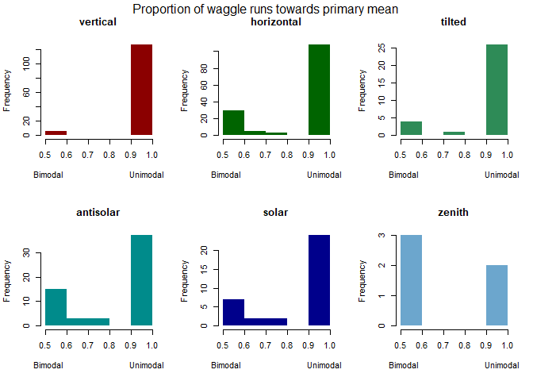

```r
par(mfrow = c(2,3))
for (cond in names(cond_cols)) {
with(
    subset(
      mean_vectors,
      condition %in% cond
    ),
    {
      hist(bim_weight1,
     breaks = (5:10)/10,#bins 0.1 wide from 0.5 to 1.0
     main = cond,
     xlab = 'Bimodal                            Unimodal',
     col = cond_cols[[cond]],
     border = NA)
    }
  )
}
mtext(side = 3,
      outer = TRUE,
      line = -1.5,
      text = "Proportion of waggle runs towards primary mean")
```

### By sun elevation

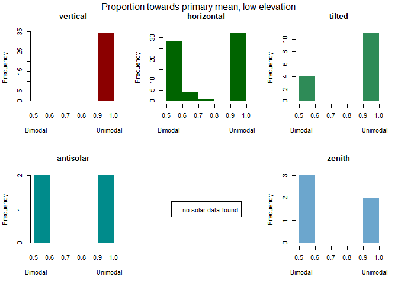

```r
#Low elevation
par(mfrow = c(2,3))
for (cond in names(cond_cols)) {
with(
    subset(
      mean_vectors,
      sun_el < 15 &
      condition %in% cond
    ),
    {
      if(length(bim_weight1) == 0)
      {
        plot(
        NULL,
        axes = FALSE,
        xlim = c(0, 0),
        ylim = c(0, 0),
        xlab = "",
        ylab = "",
        main = ""
      )
      legend(
        x = "center",
        legend = paste(
          "no",
          cond,
          "data found"
        )
      )
      }else
      {
      hist(bim_weight1,
     breaks = (5:10)/10,#bins 0.1 wide from 0.5 to 1.0
     main = cond,
     xlab = 'Bimodal                            Unimodal',
     col = cond_cols[[cond]],
     border = NA)
      }
    }
  )
}
mtext(side = 3,
      outer = TRUE,
      line = -1.5,
      text = "Proportion towards primary mean, low elevation")
```

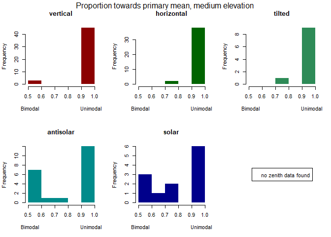

```r
#Medium elevation
for (cond in names(cond_cols)) {
with(
    subset(
      mean_vectors,
      sun_el > 30 & sun_el < 45 &
      condition %in% cond
    ),
    {
      if(length(bim_weight1) == 0)
      {
        plot(
        NULL,
        axes = FALSE,
        xlim = c(0, 0),
        ylim = c(0, 0),
        xlab = "",
        ylab = "",
        main = ""
      )
      legend(
        x = "center",
        legend = paste(
          "no",
          cond,
          "data found"
        )
      )
      }else
      {
      hist(bim_weight1,
     breaks = (5:10)/10,#bins 0.1 wide from 0.5 to 1.0
     main = cond,
     xlab = 'Bimodal                            Unimodal',
     col = cond_cols[[cond]],
     border = NA)
      }
    }
  )
}
mtext(side = 3,
      outer = TRUE,
      line = -1.5,
      text = "Proportion towards primary mean, medium elevation")
```

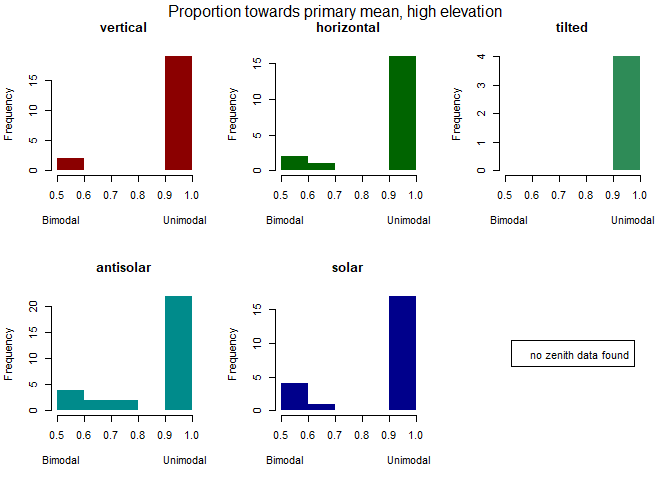

```r
#High elevation
for (cond in names(cond_cols)) {
with(
    subset(
      mean_vectors,
      sun_el > 75 &
      condition %in% cond
    ),
    {
      if(length(bim_weight1) == 0)
      {
        plot(
        NULL,
        axes = FALSE,
        xlim = c(0, 0),
        ylim = c(0, 0),
        xlab = "",
        ylab = "",
        main = ""
      )
      legend(
        x = "center",
        legend = paste(
          "no",
          cond,
          "data found"
        )
      )
      }else
      {
      hist(bim_weight1,
     breaks = (5:10)/10,#bins 0.1 wide from 0.5 to 1.0
     main = cond,
     xlab = 'Bimodal                            Unimodal',
     col = cond_cols[[cond]],
     border = NA)
      }
    }
  )
}
mtext(side = 3,
      outer = TRUE,
      line = -1.5,
      text = "Proportion towards primary mean, high elevation")
```

## Consistency

### By condition

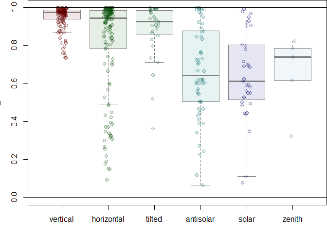

```r
par(mar = c(3, 3, 0, 0))
boxplot(mean_vector~condition,
        data = mean_vectors,
        ylim = c(0,1),
        col = adjustcolor(cond_cols, alpha.f = 0.1),
        border = 'gray50',
        outline = FALSE)
stripchart(mean_vector~condition,
           data = mean_vectors,
           add = TRUE,
           vertical = TRUE,
           method = 'jitter',
           col = adjustcolor(cond_cols, alpha.f = 0.5),
           bg = gray(level = 0,
                     alpha = 0.1),
           pch = 21)
#Identify stimuli
abline(h = c(0,1))
```

```r
mv_agg =  aggregate(mean_vector~condition,
           data = mean_vectors,
           FUN = quantile,
           probs = c(0.5, 0.25, 0.75))
rownames(mv_agg) = with(hd, levels(condition))
mv_agg = within(mv_agg, rm(condition))
mv_agg = t(apply(mv_agg, MARGIN = 1, unlist))
print(mv_agg,
  digits = 3)
```

```
##            mean_vector.50% mean_vector.25% mean_vector.75%
## vertical             0.975           0.938           0.986
## horizontal           0.944           0.791           0.984
## tilted               0.927           0.859           0.984
## antisolar            0.644           0.504           0.876
## solar                0.611           0.514           0.803
## zenith               0.738           0.616           0.785
```

### By time of day

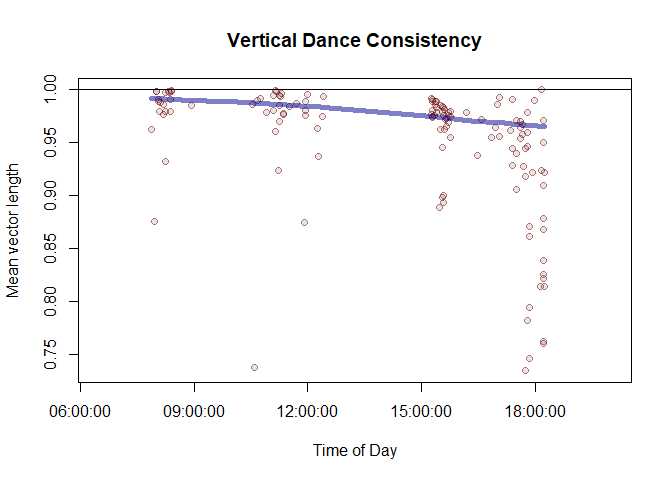

```r
plot(
  mean_vector ~ GetToD(time),
  data = subset(
    mean_vectors,
    condition %in% "vertical"
  ),
  xlim = range(exper_times) + 60*60*c(-1,1),#experiment range +-1h
  # ylim = c(0, 1)+ c(1,0)*0.5,
  xlab = "Time of Day",
  ylab = "Mean vector length",
  main = "Vertical Dance Consistency",
  col = adjustcolor(
    cond_cols$vertical,
    alpha.f = 0.5
  ),
  bg = gray(level = 0, alpha = 0.1),
  pch = 21
)
abline(h = c(0, 1))
#add smooth curve
with(
  subset(
    mean_vectors,
    condition %in% c("vertical")
  ),
  {
    lines(
      LogitLoess(
        x = GetToD(time),
        y = mean_vector
      ),

      col = adjustcolor(col = 'darkblue', alpha.f = 0.5),
      lwd = 5
    )
  }
)
```